# CUDA LAB - Transfer Learning

## Required Libraries

```python
import os
from tqdm import tqdm
import numpy as np
import matplotlib.pyplot as plt

import torch
import torch.nn as nn
import torchvision
from torchvision import datasets, models, transforms
from sklearn.metrics import confusion_matrix

import seaborn as sns

import pandas as pd
import time
from sklearn.model_selection import train_test_split
from sklearn.metrics import accuracy_score, confusion_matrix, classification_report
from sklearn.pipeline import make_pipeline
from sklearn.preprocessing import StandardScaler
```

## Data preprocessing

### Python code to change names of screenshots named as robot(1).png,robot(2).png,robot(3).png,..... to robot1.png,robot2.png,robot3.png,.....

```python
"""
import os
os.getcwd()
collection = 'C:\\Users\\Pahul\\Pictures\\Screenshots\\robot1\\'
for i, filename in enumerate(os.listdir(collection)):
    os.rename('C:\\Users\\Pahul\\Pictures\\Screenshots\\robot1\\' + filename, "robot" + str(i+1) + ".png")

"""
```

### Python code to mirror all images in a folder

```python
"""
import os
import cv2
os.getcwd()
directory = 'C:\\Users\\Pahul\\Pictures\\Screenshots\\main\\robot\\'
i=1
for file in os.listdir(directory):
     img = cv2.imread(directory + file)
     mirror_img = cv2.flip( img, 1 )
     cv2.imwrite("robot_aug"+str(i)+".png",mirror_img)
     i=i+1
"""
```

### "RandomResizedCrop" transformation was important as in intital experiments the screenshots size was large and it caused the final image after transformation sometimes without the robot or people's images without any major feature. As a result the default scale and ratio was not used and it was changed to scale=(0.95, 1.0), ratio=(1.0, 1.1)and this gave us images with all the content

### ColorJitter was explored but the original image without jitter transform gave nice results

```python
# Data augmentation and normalization for training
# Just normalization for validation
data_transforms = {
    'train': transforms.Compose([
        transforms.RandomResizedCrop(256,scale=(0.95, 1.0), ratio=(1.0, 1.1)),
        #transforms.ColorJitter(brightness=2, contrast=2, saturation=3, hue=0.3),
        #transforms.RandomHorizontalFlip(),
        transforms.ToTensor(),
        transforms.Normalize([0.485, 0.456, 0.406], [0.229, 0.224, 0.225])
    ]),
    'val': transforms.Compose([
        transforms.Resize(256),
        transforms.CenterCrop(256),
        transforms.ToTensor(),
        transforms.Normalize([0.485, 0.456, 0.406], [0.229, 0.224, 0.225])
    ]),
}
#data_dir = 'data/hymenoptera_data'
data_dir = 'data/robot_vs_people'

train_dataset = datasets.ImageFolder(os.path.join(data_dir, "train"), data_transforms["train"])
valid_dataset = datasets.ImageFolder(os.path.join(data_dir, "val"), data_transforms["val"])

N_train = len(train_dataset)
N_valid = len(valid_dataset)
print(f"Training set size: {N_train} images")
print(f"Valdiation set size: {N_valid} images")

train_loader = torch.utils.data.DataLoader(train_dataset, batch_size=12, shuffle=True, num_workers=4)
valid_loader = torch.utils.data.DataLoader(valid_dataset, batch_size=12, shuffle=True, num_workers=4)
```

```
Training set size: 360 images
Valdiation set size: 60 images
```

```python
class_names = train_dataset.classes
print(class_names)
```

```
['person', 'robot']
```

```python
device = torch.device("cuda" if torch.cuda.is_available() else "cpu")
print(device)
```

```
cuda
```

## The images of robots are all screenshots from the videos provided

## However, for people images, different scenarios were involved i.e. football players, simple images of people in natural backgrounds and images of faces in some cases

#### Here, this was run on my machine which had 6gb graphic card and hence batch size were kept at 12 but the images shown below were on batchsize 32

[figure not shown]

```python
def show_grid(data, titles=None):
    """Imshow for Tensor."""
    data = data.numpy().transpose((0, 2, 3, 1))
    mean = np.array([0.485, 0.456, 0.406])
    std = np.array([0.229, 0.224, 0.225])
    data = std * data + mean
    data = np.clip(data, 0, 1)

    plt.figure(figsize=(8*2, 4*2))
    for i in range(32):
        plt.subplot(4,8,i+1)
        plt.imshow(data[i])
        plt.axis("off")
        if titles is not None:
            plt.title(titles[i])
    plt.tight_layout()
    plt.show()

# Get a batch of training data and displaying it
inputs, classes = next(iter(train_loader))
titles = [class_names[x] for x in classes]

show_grid(inputs, titles=titles)
```

## The code provided previously in session4 is used for training, evaluating, saving

```python
def train_epoch(model, train_loader, optimizer, criterion, epoch, device):
    """ Training a model for one epoch """

    loss_list = []
    for i, (images, labels) in enumerate(train_loader):
        images = images.to(device)
        labels = labels.to(device)

        # Clear gradients w.r.t. parameters
        optimizer.zero_grad()

        # Forward pass to get output/logits
        outputs = model(images)

        # Calculate Loss: softmax --> cross entropy loss
        loss = criterion(outputs, labels)
        loss_list.append(loss.item())

        # Getting gradients w.r.t. parameters
        loss.backward()

        # Updating parameters
        optimizer.step()

    mean_loss = np.mean(loss_list)
    return mean_loss, loss_list


@torch.no_grad()
def eval_model(model, eval_loader, criterion, device):
    """ Evaluating the model for either validation or test """
    correct = 0
    total = 0
    loss_list = []

    for images, labels in eval_loader:
        images = images.to(device)
        labels = labels.to(device)

        # Forward pass only to get logits/output
        outputs = model(images)

        loss = criterion(outputs, labels)
        loss_list.append(loss.item())

        # Get predictions from the maximum value
        preds = torch.argmax(outputs, dim=1)
        correct += len( torch.where(preds==labels)[0] )
        total += len(labels)

    # Total correct predictions and loss
    accuracy = correct / total * 100
    loss = np.mean(loss_list)

    return accuracy, loss


def train_model(model, optimizer, scheduler, criterion, train_loader, valid_loader, num_epochs):
    """ Training a model for a given number of epochs"""

    train_loss = []
    val_loss =  []
    loss_iters = []
    valid_acc = []

    for epoch in range(num_epochs):

        # validation epoch
        model.eval()  # important for dropout and batch norms
        accuracy, loss = eval_model(
                    model=model, eval_loader=valid_loader,
                    criterion=criterion, device=device
            )
        valid_acc.append(accuracy)
        val_loss.append(loss)

        # training epoch
        model.train()  # important for dropout and batch norms
        mean_loss, cur_loss_iters = train_epoch(
                model=model, train_loader=train_loader, optimizer=optimizer,
                criterion=criterion, epoch=epoch, device=device
            )
        scheduler.step()
        train_loss.append(mean_loss)
        loss_iters = loss_iters + cur_loss_iters

        if(epoch % 5 == 0 or epoch==num_epochs-1):
            print(f"Epoch {epoch+1}/{num_epochs}")
            print(f"    Train loss: {round(mean_loss, 5)}")
            print(f"    Valid loss: {round(loss, 5)}")
            print(f"    Accuracy: {accuracy}%")
            print("\n")

    print(f"Training completed")
    return train_loss, val_loss, loss_iters, valid_acc
```

```python
def save_model(model, optimizer, epoch, stats):
    """ Saving model checkpoint """

    if(not os.path.exists("models")):
        os.makedirs("models")
    savepath = f"models/checkpoint_epoch_{epoch}.pth"

    torch.save({
        'epoch': epoch,
        'model_state_dict': model.state_dict(),
        'optimizer_state_dict': optimizer.state_dict(),
        'stats': stats
    }, savepath)
    return


def load_model(model, optimizer, savepath):
    """ Loading pretrained checkpoint """

    checkpoint = torch.load(savepath)
    model.load_state_dict(checkpoint['model_state_dict'])
    optimizer.load_state_dict(checkpoint['optimizer_state_dict'])
    epoch = checkpoint["epoch"]
    stats = checkpoint["stats"]

    return model, optimizer, epoch, stats


def smooth(f, K=5):
    """ Smoothing a function using a low-pass filter (mean) of size K """
    kernel = np.ones(K) / K
    f = np.concatenate([f[:int(K//2)], f, f[int(-K//2):]])  # to account for boundaries
    smooth_f = np.convolve(f, kernel, mode="same")
    smooth_f = smooth_f[K//2: -K//2]  # removing boundary-fixes
    return smooth_f

def set_random_seed(random_seed=None):
    """
    Using random seed for numpy and torch
    """
    if(random_seed is None):
        random_seed = 13
    os.environ['PYTHONHASHSEED'] = str(random_seed)
    np.random.seed(random_seed)
    torch.manual_seed(random_seed)
    torch.cuda.manual_seed_all(random_seed)
    return
```

```python
def count_model_params(model):
    """ Counting the number of learnable parameters in a nn.Module """
    num_params = sum(p.numel() for p in model.parameters() if p.requires_grad)
    return num_params
```

```python
set_random_seed()
```

# Fine-tune VGG, ResNet and DenseNet for out custom dataset of humanoid robot classification (Binary classification Robot v.s. Human) and comparison.

### ResNet

```python
# downloading pretrained model
model = models.resnet18(pretrained=True)  # https://github.com/pytorch/vision/blob/master/torchvision/models/resnet.py

# replacing classification head
num_nuerons = model.fc.in_features
model.fc = nn.Linear(num_nuerons, 2)

model = model.to(device)
print(model)
```

```
ResNet(
  (conv1): Conv2d(3, 64, kernel_size=(7, 7), stride=(2, 2), padding=(3, 3), bias=False)
  (bn1): BatchNorm2d(64, eps=1e-05, momentum=0.1, affine=True, track_running_stats=True)
  (relu): ReLU(inplace=True)
  (maxpool): MaxPool2d(kernel_size=3, stride=2, padding=1, dilation=1, ceil_mode=False)
  (layer1): Sequential(
    (0): BasicBlock(
      (conv1): Conv2d(64, 64, kernel_size=(3, 3), stride=(1, 1), padding=(1, 1), bias=False)
      (bn1): BatchNorm2d(64, eps=1e-05, momentum=0.1, affine=True, track_running_stats=True)
      (relu): ReLU(inplace=True)
      (conv2): Conv2d(64, 64, kernel_size=(3, 3), stride=(1, 1), padding=(1, 1), bias=False)
      (bn2): BatchNorm2d(64, eps=1e-05, momentum=0.1, affine=True, track_running_stats=True)
    )
    (1): BasicBlock(
      (conv1): Conv2d(64, 64, kernel_size=(3, 3), stride=(1, 1), padding=(1, 1), bias=False)
      (bn1): BatchNorm2d(64, eps=1e-05, momentum=0.1, affine=True, track_running_stats=True)
      (relu): ReLU(inplace=True)
      (conv2): Conv2d(64, 64, kernel_size=(3, 3), stride=(1, 1), padding=(1, 1), bias=False)
      (bn2): BatchNorm2d(64, eps=1e-05, momentum=0.1, affine=True, track_running_stats=True)
    )
  )
  (layer2): Sequential(
    (0): BasicBlock(
      (conv1): Conv2d(64, 128, kernel_size=(3, 3), stride=(2, 2), padding=(1, 1), bias=False)
      (bn1): BatchNorm2d(128, eps=1e-05, momentum=0.1, affine=True, track_running_stats=True)
      (relu): ReLU(inplace=True)
      (conv2): Conv2d(128, 128, kernel_size=(3, 3), stride=(1, 1), padding=(1, 1), bias=False)
      (bn2): BatchNorm2d(128, eps=1e-05, momentum=0.1, affine=True, track_running_stats=True)
      (downsample): Sequential(
        (0): Conv2d(64, 128, kernel_size=(1, 1), stride=(2, 2), bias=False)
        (1): BatchNorm2d(128, eps=1e-05, momentum=0.1, affine=True, track_running_stats=True)
      )
    )
    (1): BasicBlock(
      (conv1): Conv2d(128, 128, kernel_size=(3, 3), stride=(1, 1), padding=(1, 1), bias=False)
      (bn1): BatchNorm2d(128, eps=1e-05, momentum=0.1, affine=True, track_running_stats=True)
      (relu): ReLU(inplace=True)
      (conv2): Conv2d(128, 128, kernel_size=(3, 3), stride=(1, 1), padding=(1, 1), bias=False)
      (bn2): BatchNorm2d(128, eps=1e-05, momentum=0.1, affine=True, track_running_stats=True)
    )
```

[output cut: 29 more lines]

```
        (0): Conv2d(256, 512, kernel_size=(1, 1), stride=(2, 2), bias=False)
        (1): BatchNorm2d(512, eps=1e-05, momentum=0.1, affine=True, track_running_stats=True)
      )
    )
    (1): BasicBlock(
      (conv1): Conv2d(512, 512, kernel_size=(3, 3), stride=(1, 1), padding=(1, 1), bias=False)
      (bn1): BatchNorm2d(512, eps=1e-05, momentum=0.1, affine=True, track_running_stats=True)
      (relu): ReLU(inplace=True)
      (conv2): Conv2d(512, 512, kernel_size=(3, 3), stride=(1, 1), padding=(1, 1), bias=False)
      (bn2): BatchNorm2d(512, eps=1e-05, momentum=0.1, affine=True, track_running_stats=True)
    )
  )
  (avgpool): AdaptiveAvgPool2d(output_size=(1, 1))
  (fc): Linear(in_features=512, out_features=2, bias=True)
)
```

```python
# classification loss function
criterion = nn.CrossEntropyLoss()

# Observe that all parameters are being optimized
optimizer = torch.optim.Adam(model.parameters(), lr=3e-4)

# Decay LR by a factor of 0.1 every 7 epochs
scheduler = torch.optim.lr_scheduler.StepLR(optimizer, step_size=7, gamma=0.1)
```

```python
start = time.time()
train_loss, val_loss, loss_iters, valid_acc = train_model(
        model=model, optimizer=optimizer, scheduler=scheduler, criterion=criterion,
        train_loader=train_loader, valid_loader=valid_loader, num_epochs=10
    )
end = time.time()
```

```
    Train loss: 0.0419
    Valid loss: 0.84938
    Accuracy: 40.0%


    Train loss: 0.01282
    Valid loss: 0.02487
    Accuracy: 98.33333333333333%


    Train loss: 0.00064
    Valid loss: 0.02812
    Accuracy: 98.33333333333333%


Training completed
```

```python
print("Time Elapsed = ",end-start," seconds")
```

```
Time Elapsed =  46.90447020530701  seconds
```

```python
print(count_model_params(model))
```

```
11177538
```

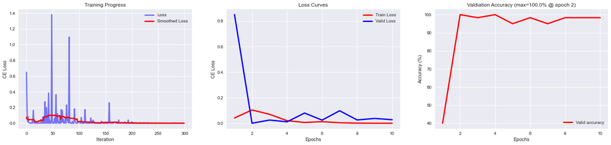

```python
plt.style.use('seaborn')
fig, ax = plt.subplots(1,3)
fig.set_size_inches(24,5)

smooth_loss = smooth(loss_iters, 31)
ax[0].plot(loss_iters, c="blue", label="Loss", linewidth=3, alpha=0.5)
ax[0].plot(smooth_loss, c="red", label="Smoothed Loss", linewidth=3, alpha=1)
ax[0].legend(loc="best")
ax[0].set_xlabel("Iteration")
ax[0].set_ylabel("CE Loss")
ax[0].set_title("Training Progress")

epochs = np.arange(len(train_loss)) + 1
ax[1].plot(epochs, train_loss, c="red", label="Train Loss", linewidth=3)
ax[1].plot(epochs, val_loss, c="blue", label="Valid Loss", linewidth=3)
ax[1].legend(loc="best")
ax[1].set_xlabel("Epochs")
ax[1].set_ylabel("CE Loss")
ax[1].set_title("Loss Curves")

epochs = np.arange(len(val_loss)) + 1
ax[2].plot(epochs, valid_acc, c="red", label="Valid accuracy", linewidth=3)
ax[2].legend(loc="best")
ax[2].set_xlabel("Epochs")
ax[2].set_ylabel("Accuracy (%)")
ax[2].set_title(f"Valdiation Accuracy (max={round(np.max(valid_acc),2)}% @ epoch {np.argmax(valid_acc)+1})")

plt.show()
```

```python
num = list(range(0,10))
df = pd.DataFrame(num, columns = ['Epochs'])
df['Train Loss'] = pd.DataFrame(train_loss)
df['Validation Loss'] = pd.DataFrame(val_loss)
df['Validation Acc'] = pd.DataFrame(valid_acc)
df.to_csv('finetune_resnet.csv', sep=',',index = False)
df1 = pd.read_csv('finetune_resnet.csv')
df1.head(10)
```

|  | Epochs | Train Loss | Validation Loss | Validation Acc |
| --- | --- | --- | --- | --- |
| 0 | 0 | 0.041905 | 0.849376 | 40.000000 |
| 1 | 1 | 0.104246 | 0.000652 | 100.000000 |
| 2 | 2 | 0.070442 | 0.025318 | 98.333333 |
| 3 | 3 | 0.020407 | 0.011660 | 100.000000 |
| 4 | 4 | 0.006721 | 0.080117 | 95.000000 |
| 5 | 5 | 0.012821 | 0.024871 | 98.333333 |
| 6 | 6 | 0.004384 | 0.098044 | 95.000000 |
| 7 | 7 | 0.001432 | 0.026269 | 98.333333 |
| 8 | 8 | 0.000580 | 0.038011 | 98.333333 |
| 9 | 9 | 0.000640 | 0.028122 | 98.333333 |

### VGG

```python
# downloading pretrained model
model = models.vgg16(pretrained=True)

#https://www.kaggle.com/carloalbertobarbano/vgg16-transfer-learning-pytorch

num_features = model.classifier[6].in_features
features = list(model.classifier.children())[:-1] # Remove last layer
features.extend([nn.Linear(num_features, 2)]) # Add our layer with 2 outputs namely person and robot
model.classifier = nn.Sequential(*features) # Replace the model classifier
print(model)

model = model.to(device)
```

```
VGG(
  (features): Sequential(
    (0): Conv2d(3, 64, kernel_size=(3, 3), stride=(1, 1), padding=(1, 1))
    (1): ReLU(inplace=True)
    (2): Conv2d(64, 64, kernel_size=(3, 3), stride=(1, 1), padding=(1, 1))
    (3): ReLU(inplace=True)
    (4): MaxPool2d(kernel_size=2, stride=2, padding=0, dilation=1, ceil_mode=False)
    (5): Conv2d(64, 128, kernel_size=(3, 3), stride=(1, 1), padding=(1, 1))
    (6): ReLU(inplace=True)
    (7): Conv2d(128, 128, kernel_size=(3, 3), stride=(1, 1), padding=(1, 1))
    (8): ReLU(inplace=True)
    (9): MaxPool2d(kernel_size=2, stride=2, padding=0, dilation=1, ceil_mode=False)
    (10): Conv2d(128, 256, kernel_size=(3, 3), stride=(1, 1), padding=(1, 1))
    (11): ReLU(inplace=True)
    (12): Conv2d(256, 256, kernel_size=(3, 3), stride=(1, 1), padding=(1, 1))
    (13): ReLU(inplace=True)
    (14): Conv2d(256, 256, kernel_size=(3, 3), stride=(1, 1), padding=(1, 1))
    (15): ReLU(inplace=True)
    (16): MaxPool2d(kernel_size=2, stride=2, padding=0, dilation=1, ceil_mode=False)
    (17): Conv2d(256, 512, kernel_size=(3, 3), stride=(1, 1), padding=(1, 1))
    (18): ReLU(inplace=True)
    (19): Conv2d(512, 512, kernel_size=(3, 3), stride=(1, 1), padding=(1, 1))
    (20): ReLU(inplace=True)
    (21): Conv2d(512, 512, kernel_size=(3, 3), stride=(1, 1), padding=(1, 1))
    (22): ReLU(inplace=True)
    (23): MaxPool2d(kernel_size=2, stride=2, padding=0, dilation=1, ceil_mode=False)
    (24): Conv2d(512, 512, kernel_size=(3, 3), stride=(1, 1), padding=(1, 1))
    (25): ReLU(inplace=True)
    (26): Conv2d(512, 512, kernel_size=(3, 3), stride=(1, 1), padding=(1, 1))
    (27): ReLU(inplace=True)
    (28): Conv2d(512, 512, kernel_size=(3, 3), stride=(1, 1), padding=(1, 1))
    (29): ReLU(inplace=True)
    (30): MaxPool2d(kernel_size=2, stride=2, padding=0, dilation=1, ceil_mode=False)
  )
  (avgpool): AdaptiveAvgPool2d(output_size=(7, 7))
  (classifier): Sequential(
    (0): Linear(in_features=25088, out_features=4096, bias=True)
    (1): ReLU(inplace=True)
    (2): Dropout(p=0.5, inplace=False)
    (3): Linear(in_features=4096, out_features=4096, bias=True)
    (4): ReLU(inplace=True)
    (5): Dropout(p=0.5, inplace=False)
    (6): Linear(in_features=4096, out_features=2, bias=True)
  )
)
```

```python
# classification loss function
criterion = nn.CrossEntropyLoss()

# Observe that all parameters are being optimized
optimizer = torch.optim.Adam(model.parameters(), lr=3e-4)

# Decay LR by a factor of 0.1 every 7 epochs
scheduler = torch.optim.lr_scheduler.StepLR(optimizer, step_size=7, gamma=0.1)
```

```python
start = time.time()
train_loss, val_loss, loss_iters, valid_acc = train_model(
        model=model, optimizer=optimizer, scheduler=scheduler, criterion=criterion,
        train_loader=train_loader, valid_loader=valid_loader, num_epochs=10
    )
end = time.time()
```

```
    Train loss: 0.79447
    Valid loss: 0.8001
    Accuracy: 38.333333333333336%


    Train loss: 0.21613
    Valid loss: 0.17376
    Accuracy: 91.66666666666666%


    Train loss: 0.02111
    Valid loss: 0.14453
    Accuracy: 91.66666666666666%


Training completed
```

```python
print("Time Elapsed = ",end-start," seconds")
```

```
Time Elapsed =  110.0323052406311  seconds
```

```python
print(count_model_params(model))
```

```
134268738
```

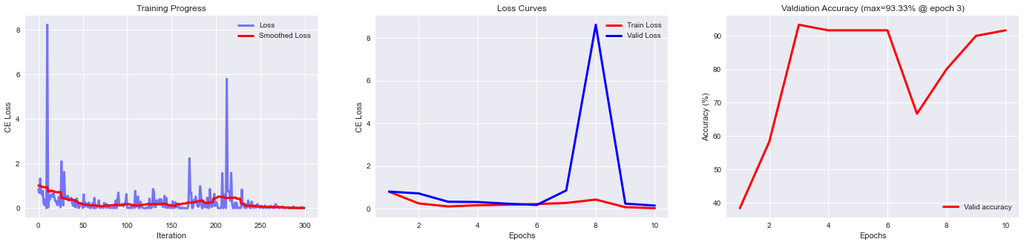

```python
plt.style.use('seaborn')
fig, ax = plt.subplots(1,3)
fig.set_size_inches(24,5)

smooth_loss = smooth(loss_iters, 31)
ax[0].plot(loss_iters, c="blue", label="Loss", linewidth=3, alpha=0.5)
ax[0].plot(smooth_loss, c="red", label="Smoothed Loss", linewidth=3, alpha=1)
ax[0].legend(loc="best")
ax[0].set_xlabel("Iteration")
ax[0].set_ylabel("CE Loss")
ax[0].set_title("Training Progress")

epochs = np.arange(len(train_loss)) + 1
ax[1].plot(epochs, train_loss, c="red", label="Train Loss", linewidth=3)
ax[1].plot(epochs, val_loss, c="blue", label="Valid Loss", linewidth=3)
ax[1].legend(loc="best")
ax[1].set_xlabel("Epochs")
ax[1].set_ylabel("CE Loss")
ax[1].set_title("Loss Curves")

epochs = np.arange(len(val_loss)) + 1
ax[2].plot(epochs, valid_acc, c="red", label="Valid accuracy", linewidth=3)
ax[2].legend(loc="best")
ax[2].set_xlabel("Epochs")
ax[2].set_ylabel("Accuracy (%)")
ax[2].set_title(f"Valdiation Accuracy (max={round(np.max(valid_acc),2)}% @ epoch {np.argmax(valid_acc)+1})")

plt.show()
```

```python
num = list(range(0,10))
df = pd.DataFrame(num, columns = ['Epochs'])
df['Train Loss'] = pd.DataFrame(train_loss)
df['Validation Loss'] = pd.DataFrame(val_loss)
df['Validation Acc'] = pd.DataFrame(valid_acc)
df.to_csv('finetune_vgg.csv', sep=',',index = False)
df1 = pd.read_csv('finetune_vgg.csv')
df1.head(10)
```

|  | Epochs | Train Loss | Validation Loss | Validation Acc |
| --- | --- | --- | --- | --- |
| 0 | 0 | 0.794469 | 0.800095 | 38.333333 |
| 1 | 1 | 0.245533 | 0.714437 | 58.333333 |
| 2 | 2 | 0.104540 | 0.324041 | 93.333333 |
| 3 | 3 | 0.160423 | 0.311578 | 91.666667 |
| 4 | 4 | 0.186196 | 0.233779 | 91.666667 |
| 5 | 5 | 0.216134 | 0.173763 | 91.666667 |
| 6 | 6 | 0.268217 | 0.854218 | 66.666667 |
| 7 | 7 | 0.425857 | 8.620956 | 80.000000 |
| 8 | 8 | 0.068616 | 0.234343 | 90.000000 |
| 9 | 9 | 0.021110 | 0.144527 | 91.666667 |

### Densenet

```python
# downloading pretrained model
model = models.densenet161(pretrained=True)
#https://discuss.pytorch.org/t/pytorch-transfer-learning-with-densenet/15579/4

num_ftrs = model.classifier.in_features
model.classifier = nn.Linear(num_ftrs, 2)
print(model)

model = model.to(device)
```

```
DenseNet(
  (features): Sequential(
    (conv0): Conv2d(3, 96, kernel_size=(7, 7), stride=(2, 2), padding=(3, 3), bias=False)
    (norm0): BatchNorm2d(96, eps=1e-05, momentum=0.1, affine=True, track_running_stats=True)
    (relu0): ReLU(inplace=True)
    (pool0): MaxPool2d(kernel_size=3, stride=2, padding=1, dilation=1, ceil_mode=False)
    (denseblock1): _DenseBlock(
      (denselayer1): _DenseLayer(
        (norm1): BatchNorm2d(96, eps=1e-05, momentum=0.1, affine=True, track_running_stats=True)
        (relu1): ReLU(inplace=True)
        (conv1): Conv2d(96, 192, kernel_size=(1, 1), stride=(1, 1), bias=False)
        (norm2): BatchNorm2d(192, eps=1e-05, momentum=0.1, affine=True, track_running_stats=True)
        (relu2): ReLU(inplace=True)
        (conv2): Conv2d(192, 48, kernel_size=(3, 3), stride=(1, 1), padding=(1, 1), bias=False)
      )
      (denselayer2): _DenseLayer(
        (norm1): BatchNorm2d(144, eps=1e-05, momentum=0.1, affine=True, track_running_stats=True)
        (relu1): ReLU(inplace=True)
        (conv1): Conv2d(144, 192, kernel_size=(1, 1), stride=(1, 1), bias=False)
        (norm2): BatchNorm2d(192, eps=1e-05, momentum=0.1, affine=True, track_running_stats=True)
        (relu2): ReLU(inplace=True)
        (conv2): Conv2d(192, 48, kernel_size=(3, 3), stride=(1, 1), padding=(1, 1), bias=False)
      )
      (denselayer3): _DenseLayer(
        (norm1): BatchNorm2d(192, eps=1e-05, momentum=0.1, affine=True, track_running_stats=True)
        (relu1): ReLU(inplace=True)
        (conv1): Conv2d(192, 192, kernel_size=(1, 1), stride=(1, 1), bias=False)
        (norm2): BatchNorm2d(192, eps=1e-05, momentum=0.1, affine=True, track_running_stats=True)
        (relu2): ReLU(inplace=True)
        (conv2): Conv2d(192, 48, kernel_size=(3, 3), stride=(1, 1), padding=(1, 1), bias=False)
      )
      (denselayer4): _DenseLayer(
        (norm1): BatchNorm2d(240, eps=1e-05, momentum=0.1, affine=True, track_running_stats=True)
        (relu1): ReLU(inplace=True)
        (conv1): Conv2d(240, 192, kernel_size=(1, 1), stride=(1, 1), bias=False)
        (norm2): BatchNorm2d(192, eps=1e-05, momentum=0.1, affine=True, track_running_stats=True)
        (relu2): ReLU(inplace=True)
        (conv2): Conv2d(192, 48, kernel_size=(3, 3), stride=(1, 1), padding=(1, 1), bias=False)
      )
      (denselayer5): _DenseLayer(
```

[output cut: 605 more lines]

```
        (conv2): Conv2d(192, 48, kernel_size=(3, 3), stride=(1, 1), padding=(1, 1), bias=False)
      )
      (denselayer24): _DenseLayer(
        (norm1): BatchNorm2d(2160, eps=1e-05, momentum=0.1, affine=True, track_running_stats=True)
        (relu1): ReLU(inplace=True)
        (conv1): Conv2d(2160, 192, kernel_size=(1, 1), stride=(1, 1), bias=False)
        (norm2): BatchNorm2d(192, eps=1e-05, momentum=0.1, affine=True, track_running_stats=True)
        (relu2): ReLU(inplace=True)
        (conv2): Conv2d(192, 48, kernel_size=(3, 3), stride=(1, 1), padding=(1, 1), bias=False)
      )
    )
    (norm5): BatchNorm2d(2208, eps=1e-05, momentum=0.1, affine=True, track_running_stats=True)
  )
  (classifier): Linear(in_features=2208, out_features=2, bias=True)
)
```

```python
# classification loss function
criterion = nn.CrossEntropyLoss()

# Observe that all parameters are being optimized
optimizer = torch.optim.Adam(model.parameters(), lr=3e-4)

# Decay LR by a factor of 0.1 every 7 epochs
scheduler = torch.optim.lr_scheduler.StepLR(optimizer, step_size=7, gamma=0.1)
```

```python
start = time.time()
train_loss, val_loss, loss_iters, valid_acc = train_model(
        model=model, optimizer=optimizer, scheduler=scheduler, criterion=criterion,
        train_loader=train_loader, valid_loader=valid_loader, num_epochs=10
    )
end = time.time()
```

```
    Train loss: 0.06408
    Valid loss: 0.6324
    Accuracy: 81.66666666666667%


    Train loss: 0.06655
    Valid loss: 0.04321
    Accuracy: 98.33333333333333%


    Train loss: 0.00951
    Valid loss: 0.07409
    Accuracy: 98.33333333333333%


Training completed
```

```python
print("Time Elapsed = ",end-start," seconds")
```

```
Time Elapsed =  136.9563159942627  seconds
```

```python
print(count_model_params(model))
```

```
26476418
```

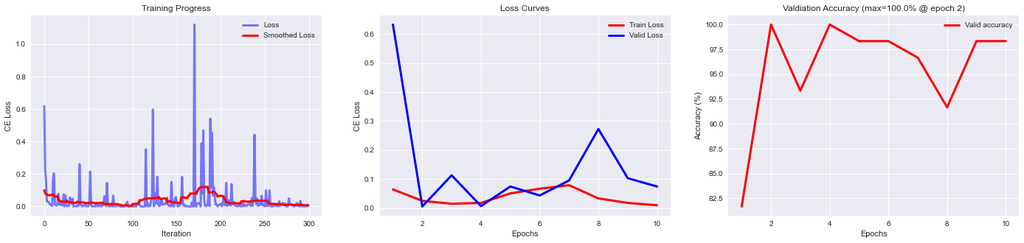

```python
plt.style.use('seaborn')
fig, ax = plt.subplots(1,3)
fig.set_size_inches(24,5)

smooth_loss = smooth(loss_iters, 31)
ax[0].plot(loss_iters, c="blue", label="Loss", linewidth=3, alpha=0.5)
ax[0].plot(smooth_loss, c="red", label="Smoothed Loss", linewidth=3, alpha=1)
ax[0].legend(loc="best")
ax[0].set_xlabel("Iteration")
ax[0].set_ylabel("CE Loss")
ax[0].set_title("Training Progress")

epochs = np.arange(len(train_loss)) + 1
ax[1].plot(epochs, train_loss, c="red", label="Train Loss", linewidth=3)
ax[1].plot(epochs, val_loss, c="blue", label="Valid Loss", linewidth=3)
ax[1].legend(loc="best")
ax[1].set_xlabel("Epochs")
ax[1].set_ylabel("CE Loss")
ax[1].set_title("Loss Curves")

epochs = np.arange(len(val_loss)) + 1
ax[2].plot(epochs, valid_acc, c="red", label="Valid accuracy", linewidth=3)
ax[2].legend(loc="best")
ax[2].set_xlabel("Epochs")
ax[2].set_ylabel("Accuracy (%)")
ax[2].set_title(f"Valdiation Accuracy (max={round(np.max(valid_acc),2)}% @ epoch {np.argmax(valid_acc)+1})")

plt.show()
```

```python
num = list(range(0,10))
df = pd.DataFrame(num, columns = ['Epochs'])
df['Train Loss'] = pd.DataFrame(train_loss)
df['Validation Loss'] = pd.DataFrame(val_loss)
df['Validation Acc'] = pd.DataFrame(valid_acc)
df.to_csv('finetune_densenet.csv', sep=',',index = False)
df1 = pd.read_csv('finetune_densenet.csv')
df1.head(10)
```

|  | Epochs | Train Loss | Validation Loss | Validation Acc |
| --- | --- | --- | --- | --- |
| 0 | 0 | 0.064075 | 0.632400 | 81.666667 |
| 1 | 1 | 0.024719 | 0.005227 | 100.000000 |
| 2 | 2 | 0.014776 | 0.112825 | 93.333333 |
| 3 | 3 | 0.017675 | 0.006666 | 100.000000 |
| 4 | 4 | 0.050438 | 0.074314 | 98.333333 |
| 5 | 5 | 0.066551 | 0.043209 | 98.333333 |
| 6 | 6 | 0.078709 | 0.095078 | 96.666667 |
| 7 | 7 | 0.033097 | 0.272398 | 91.666667 |
| 8 | 8 | 0.017660 | 0.102859 | 98.333333 |
| 9 | 9 | 0.009505 | 0.074085 | 98.333333 |

# Comparison between finetune resnet, vgg and densenet

### 1) As seen below, densenet takes the longest to train followed by VGG and then resnet.

### 2) Resnet and densenet both reach accuracy of 100 percent but max accuracy achieved for VGG was 93.33 however, when run on google collab with batchsize 32, accuracy of 98.33 was achieved with VGG in 10 epochs.

### 3) As observed in train loss plot below, resnet and densenet have smoother loss values and get trained much faster as compared to VGG.

### 4) Similarly, plots of resnet and densenet for validation loss and accuracy are much smoother than VGG.

```python
"""
=========================================
Resnet parameters   = 11177538,
Time Elapsed =  46.90447020530701  seconds
==========================================
VGG parameters      = 134268738,
Time Elapsed =  110.0323052406311  seconds
==========================================
Densenet parameters = 26476418,
Time Elapsed =  136.9563159942627  seconds
==========================================
"""
```

```python
df1 = pd.read_csv('finetune_resnet.csv')
df2 = pd.read_csv('finetune_vgg.csv')
df3 = pd.read_csv('finetune_densenet.csv')
```

```python
df=pd.DataFrame()
print("Train Loss Comparison of the 3 models")
df['Epochs for Train Loss'] = df1['Epochs']
df['Resnet'] = df1['Train Loss']
df['VGG'] = df2['Train Loss']
df['Densenet'] = df3['Train Loss']
df.head(10)
```

```
Train Loss Comparison of the 3 models
```

|  | Epochs for Train Loss | Resnet | VGG | Densenet |
| --- | --- | --- | --- | --- |
| 0 | 0 | 0.041905 | 0.794469 | 0.064075 |
| 1 | 1 | 0.104246 | 0.245533 | 0.024719 |
| 2 | 2 | 0.070442 | 0.104540 | 0.014776 |
| 3 | 3 | 0.020407 | 0.160423 | 0.017675 |
| 4 | 4 | 0.006721 | 0.186196 | 0.050438 |
| 5 | 5 | 0.012821 | 0.216134 | 0.066551 |
| 6 | 6 | 0.004384 | 0.268217 | 0.078709 |
| 7 | 7 | 0.001432 | 0.425857 | 0.033097 |
| 8 | 8 | 0.000580 | 0.068616 | 0.017660 |
| 9 | 9 | 0.000640 | 0.021110 | 0.009505 |

```python
df=pd.DataFrame()
print("Validation Loss Comparison of the 3 models")
df['Epochs for Validation Loss'] = df1['Epochs']
df['Resnet'] = df1['Validation Loss']
df['VGG'] = df2['Validation Loss']
df['Densenet'] = df3['Validation Loss']
df.head(10)
```

```
Validation Loss Comparison of the 3 models
```

|  | Epochs for Validation Loss | Resnet | VGG | Densenet |
| --- | --- | --- | --- | --- |
| 0 | 0 | 0.849376 | 0.800095 | 0.632400 |
| 1 | 1 | 0.000652 | 0.714437 | 0.005227 |
| 2 | 2 | 0.025318 | 0.324041 | 0.112825 |
| 3 | 3 | 0.011660 | 0.311578 | 0.006666 |
| 4 | 4 | 0.080117 | 0.233779 | 0.074314 |
| 5 | 5 | 0.024871 | 0.173763 | 0.043209 |
| 6 | 6 | 0.098044 | 0.854218 | 0.095078 |
| 7 | 7 | 0.026269 | 8.620956 | 0.272398 |
| 8 | 8 | 0.038011 | 0.234343 | 0.102859 |
| 9 | 9 | 0.028122 | 0.144527 | 0.074085 |

```python
df=pd.DataFrame()
print("Accuracy Comparison of the 3 models")
df['Epochs for Validation Acc'] = df1['Epochs']
df['Resnet'] = df1['Validation Acc']
df['VGG'] = df2['Validation Acc']
df['Densenet'] = df3['Validation Acc']
df.head(10)
```

```
Accuracy Comparison of the 3 models
```

|  | Epochs for Validation Acc | Resnet | VGG | Densenet |
| --- | --- | --- | --- | --- |
| 0 | 0 | 40.000000 | 38.333333 | 81.666667 |
| 1 | 1 | 100.000000 | 58.333333 | 100.000000 |
| 2 | 2 | 98.333333 | 93.333333 | 93.333333 |
| 3 | 3 | 100.000000 | 91.666667 | 100.000000 |
| 4 | 4 | 95.000000 | 91.666667 | 98.333333 |
| 5 | 5 | 98.333333 | 91.666667 | 98.333333 |
| 6 | 6 | 95.000000 | 66.666667 | 96.666667 |
| 7 | 7 | 98.333333 | 80.000000 | 91.666667 |
| 8 | 8 | 98.333333 | 90.000000 | 98.333333 |
| 9 | 9 | 98.333333 | 91.666667 | 98.333333 |

```
[Text(0.5, 0, 'Epochs'), Text(0, 0.5, 'Train Loss')]
```

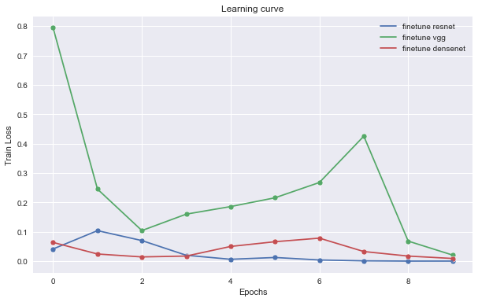

```python
fig = plt.figure()
fig = plt.figure(figsize=(10,6))
p = sns.lineplot(data=df1, x="Epochs", y="Train Loss",label = 'finetune resnet')
p = sns.scatterplot(data=df1, x="Epochs", y="Train Loss")
p = sns.lineplot(data=df2, x="Epochs", y="Train Loss", label='finetune vgg')
p = sns.scatterplot(data=df2, x="Epochs", y="Train Loss")
p = sns.lineplot(data=df3, x="Epochs", y="Train Loss", label='finetune densenet')
p = sns.scatterplot(data=df3, x="Epochs", y="Train Loss")
plt.legend()
p.set_title("Learning curve")   # change here
p.set(xlabel='Epochs', ylabel='Train Loss')
```

```
[Text(0.5, 0, 'Epochs'), Text(0, 0.5, 'Validation Loss')]
```

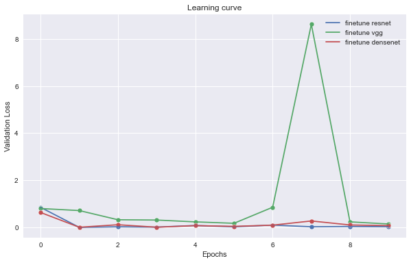

```python
fig = plt.figure()
fig = plt.figure(figsize=(10,6))
p = sns.lineplot(data=df1, x="Epochs", y="Validation Loss",label = 'finetune resnet')
p = sns.scatterplot(data=df1, x="Epochs", y="Validation Loss")
p = sns.lineplot(data=df2, x="Epochs", y="Validation Loss", label='finetune vgg')
p = sns.scatterplot(data=df2, x="Epochs", y="Validation Loss")
p = sns.lineplot(data=df3, x="Epochs", y="Validation Loss", label='finetune densenet')
p = sns.scatterplot(data=df3, x="Epochs", y="Validation Loss")
plt.legend()
p.set_title("Learning curve")   # change here
p.set(xlabel='Epochs', ylabel='Validation Loss')
```

```
[Text(0.5, 0, 'Epochs'), Text(0, 0.5, 'Validation Loss')]
```

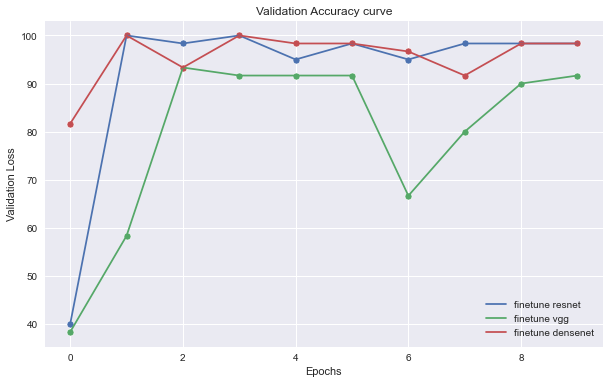

```python
fig = plt.figure()
fig = plt.figure(figsize=(10,6))
p = sns.lineplot(data=df1, x="Epochs", y="Validation Acc",label = 'finetune resnet')
p = sns.scatterplot(data=df1, x="Epochs", y="Validation Acc")
p = sns.lineplot(data=df2, x="Epochs", y="Validation Acc", label='finetune vgg')
p = sns.scatterplot(data=df2, x="Epochs", y="Validation Acc")
p = sns.lineplot(data=df3, x="Epochs", y="Validation Acc", label='finetune densenet')
p = sns.scatterplot(data=df3, x="Epochs", y="Validation Acc")
plt.legend()
p.set_title("Validation Accuracy curve")   # change here
p.set(xlabel='Epochs', ylabel='Validation Loss')
```